# Guía de Ejercicios N°2 - Nivelación Estadística

- Mostrar todo el código
- Ocultar todo el código
- Ver el código fuente

Probabilidad e Inferencia Estadística con R

Autor/a

Afiliación

Prof. Gabriel Duarte Zúñiga

Universidad Adolfo Ibáñez | DIAPP-2026

Fecha de publicación

4 de junio de 2026

# Introducción

La presente guía de ejercicios permite aplicar los conceptos abordados en la **Clase 2 de Nivelación Estadística** del DIAPP 2026. Su propósito es afianzar, mediante la práctica autónoma en `R`, los conocimientos aprendidos sobre probabilidad e inferencia estadística.

El dataset principal de los ejercicios finales corresponde a **`bdims`**, disponible en el paquete `openintro` de `R`. Este conjunto de datos contiene **507 mediciones corporales** de adultos físicamente activos (Heinz et al. 2003). En particular, nos centraremos en las siguientes variables:

| Variable | Descripción |
| --- | --- |
| `sex` | Sexo: `1` (hombre) o `0` (mujer) |
| `hgt` | Estatura, en centímetros |
| `wgt` | Peso, en kilogramos |
| `age` | Edad, en años |

**Explorar la documentación del dataset**

Para revisar el detalle completo de todas las variables del dataset, puede consultar su documentación oficial ejecutando en la consola de R:

```r
help(bdims)
```

**Antes de comenzar**

Asegúrese de tener instalados los siguientes paquetes. En caso de no tenerlos, puede instalarlos ejecutando `install.packages("nombre_paquete")` en la consola de R.

**Código**

```r
install.packages("tidyverse")
install.packages("openintro")
```

Una vez instalados, cárguelos al inicio de su script:

**Código**

```r
library(tidyverse)
library(openintro)
```

**Referencia bibliográfica de los ejercicios**

Varias de las preguntas de esta guía están basados o adaptados de los ejercicios impares del libro **OpenIntro: Introduction to Modern Statistics (2a ed.)** (Çetinkaya-Rundel y Hardin 2024), disponible en: https://openintro-ims.netlify.app/. Los números de ejercicio y capítulos de referencia se indican en cada pregunta. Las respuestas a los ejercicios impares del libro pueden encontrarse en el **Apéndice A** del mismo.

# Ejercicios

### Pregunta 1: Servicios de telecomunicaciones

**Referencia**

Ejercicio adaptado de Devore, J. L. (2016). *Probabilidad y estadística para ingeniería y ciencias* (9a ed.), p. 62 (Devore 2016).

En un suburbio residencial, el 60% de las familias suscribe el servicio de **internet** de una compañía (Evento $A$), el 80% contrata el servicio de **televisión** de esa misma compañía (Evento $B$), y el 50% contrata **ambos** servicios. Si se elige una familia al azar:

1. ¿Cuál es la probabilidad de que la familia contrate **al menos uno** de los dos servicios?
2. *(Desafío)* ¿Cuál es la probabilidad de que contrate **exactamente uno** de los dos servicios?

**Pauta**

Para usar las funciones de conjuntos vistas en clases, representamos el problema como una **población de 100 familias**. La distribución queda así:

| Grupo | Familias | N° |
| --- | --- | --- |
| Ambos servicios ($A \cap B$) | 1 – 50 | 50 |
| Solo internet ($A \cap B^c$) | 51 – 60 | 10 |
| Solo TV ($B \cap A^c$) | 61 – 90 | 30 |
| Ninguno | 91 – 100 | 10 |

**Código**

```r
S <- 1:100
A <- 1:60            # 60 familias con internet
B <- c(1:50, 61:90)  # 80 familias con TV
```

**a)** “Al menos uno” es la **unión** $A \cup B$:

**Código**

```r
length(union(A, B)) / length(S)
```

```
[1] 0.9
```

Lo mismo con la fórmula de adición: $P(A \cup B) = P(A) + P(B) - P(A \cap B) = 0{,}6 + 0{,}8 - 0{,}5 = \mathbf{0{,}9}$

**b)** “Exactamente uno” equivale a estar en $A$ sin $B$, o en $B$ sin $A$. `setdiff()` entrega la **diferencia de conjuntos** (elementos de un evento que no pertenecen al otro):

**Código**

```r
solo_A <- setdiff(A, B)   # P(A ∩ B') = 0,1
solo_B <- setdiff(B, A)   # P(B ∩ A') = 0,3

length(union(solo_A, solo_B)) / length(S)
```

```
[1] 0.4
```

$P(\text{exactamente uno}) = P(A \cap B^c) + P(B \cap A^c) = 0{,}1 + 0{,}3 = \mathbf{0{,}4}$

### Pregunta 2: Moneda cargada — Distribución Binomial

Una moneda está **cargada hacia las caras**, de modo que la probabilidad de obtener cara en cada lanzamiento es $p = 0{,}6$ y se lanza **5 veces**. Sea $X$ la variable aleatoria que representa el **número de caras** obtenidas.

1. Verifique que $X$ cumple las cuatro condiciones de la distribución binomial y enuncie sus parámetros.
2. Calcule $P(X = 3)$: la probabilidad de obtener **exactamente** 3 caras.
3. Calcule $P(X \leq 3)$: la probabilidad de obtener **a lo sumo** 3 caras.
4. Calcule $P(X > 3)$: la probabilidad de obtener **más de** 3 caras.
5. Calcule $P(1 \leq X \leq 4)$: la probabilidad de obtener **entre 1 y 4 caras**, ambos extremos inclusive.

**Pauta**

**a)** $X$ cumple las cuatro condiciones:

1. Número fijo de ensayos ($n = 5$),
2. Resultado dicotómico (cara/sello),
3. Lanzamientos independientes entre sí, y
4. Probabilidad de éxito constante ($p = 0{,}6$). Por lo tanto:
   $$X \sim \text{Binomial}(n = 5,\ p = 0{,}6)$$

Note que la moneda cargada **no invalida** ninguna condición binomial: el requisito es que $p$ sea *constante* entre ensayos, no que sea $0{,}5$.

**Código**

```r
# b) P(X = 3): pmf — exactamente 3 caras
dbinom(3, 5, 0.6)
```

```
[1] 0.3456
```

**Código**

```r
# c) P(X <= 3): cdf — a lo sumo 3 caras
pbinom(3, 5, 0.6)
```

```
[1] 0.66304
```

**Código**

```r
# d) P(X > 3): complemento de la cdf
1 - pbinom(3, 5, 0.6)
```

```
[1] 0.33696
```

**Código**

```r
# e) P(1 <= X <= 4): diferencia de cdfs
pbinom(4, 5, 0.6) - pbinom(0, 5, 0.6)
```

```
[1] 0.912
```

| Parte | Expresión | Función | Resultado |
| --- | --- | --- | --- |
| b | $P(X = 3)$ | `dbinom(3, 5, 0.6)` | 0,346 |
| c | $P(X \leq 3)$ | `pbinom(3, 5, 0.6)` | 0,663 |
| d | $P(X > 3)$ | `1 - pbinom(3, 5, 0.6)` | 0,337 |
| e | $P(1 \leq X \leq 4)$ | `pbinom(4, 5, 0.6) - pbinom(0, 5, 0.6)` | 0,912 |

**El truco del ítem (e)**

La lógica es $P(1 \leq X \leq 4) = P(X \leq 4) - P(X \leq 0)$, no $P(X \leq 4) - P(X \leq 1)$. Restar $P(X \leq 1)$ excluiría el caso $X = 1$ del resultado, que el enunciado pide incluir.

**¿Qué cambia al sesgar la moneda?**

Compare los resultados con la versión equilibrada ($p = 0{,}5$): el sesgo hacia caras desplaza toda la distribución hacia la derecha. Esto se refleja en que $P(X > 3)$ sube de 0,188 a **0,337**: con una moneda cargada, obtener 4 o 5 caras en 5 lanzamientos es casi el doble de probable.

## Pregunta 3: Área bajo la curva

**Referencia IMS**

[Ejercicio 13.8.1 — *Area under the curve, Part I*](https://openintro-ims.netlify.app/foundations-mathematical#sec-chp13-exercises)

¿Qué porcentaje de una distribución normal estándar $\mathcal{N}(\mu = 0,\ \sigma = 1)$ se encuentra en cada una de las regiones delimitadas por las siguientes desigualdades sobre $Z$? Para cada caso, primero bosqueje la curva e identifique visualmente el área; luego verifique con `pnorm()` en `R`. Aproxime sus resultados a 3 decimales usando la función `round()`

1. $Z < -1{,}35$
2. $Z > 1{,}48$
3. $-0{,}4 < Z < 1{,}5$
4. $|Z| > 2$

**Pauta**

**Código**

```r
round(pnorm(-1.35), 3)                    # a. cola izquierda
```

```
[1] 0.089
```

**Código**

```r
round(1 - pnorm(1.48), 3)                # b. cola derecha = complemento
```

```
[1] 0.069
```

**Código**

```r
round(pnorm(1.5) - pnorm(-0.4), 3)       # c. área entre dos valores
```

```
[1] 0.589
```

**Código**

```r
round(2 * (1 - pnorm(2)), 3)             # d. ambas colas (simetría)
```

```
[1] 0.046
```

| Parte | Región | Resultado |
| --- | --- | --- |
| a | $Z < -1{,}35$ | 8,9% |
| b | $Z > 1{,}48$ | 6,9% |
| c | $-0{,}4 < Z < 1{,}5$ | 58,9% |
| d | $\\|Z\\| > 2$ | 4,6% |

**Notas clave:**

- 2. requiere el complemento: `pnorm()` siempre entrega el área a la **izquierda**, por lo que el área a la derecha es `1 - pnorm(x)`.
- 3. el área entre dos valores se obtiene restando las cdf acumuladas: $P(-0{,}4 < Z < 1{,}5) = F(1{,}5) - F(-0{,}4)$.
- 4. por **simetría** de la normal estándar, $P(|Z| > 2) = 2 \times P(Z > 2)$. Este resultado es el complemento de la Regla Empírica para $\pm 2\sigma$.

### Pregunta 4: Puntajes GRE y puntajes Z

**Referencia IMS**

[Ejercicio 13.8.3 — *GRE scores, Z scores*](https://openintro-ims.netlify.app/foundations-mathematical#sec-chp13-exercises)

Sofía rindió el *Graduate Record Examination* (GRE) y obtuvo **160 puntos** en la sección de Razonamiento Verbal y **157 puntos** en la sección de Razonamiento Cuantitativo. La media del Razonamiento Verbal para todos los postulantes es 151 con desviación estándar 7, y la media del Razonamiento Cuantitativo es 153 con desviación estándar 7.67. Suponga que ambas distribuciones son aproximadamente normales.

1. Escriba la notación abreviada de cada distribución.
2. Calcule el puntaje Z de Sofía en cada sección.
3. Interprete cada puntaje Z: ¿qué dice sobre el resultado de Sofía relativo al resto de los postulantes?
4. En términos **relativos**, ¿en cuál sección le fue mejor a Sofía?
5. Calcule el **percentil** de Sofía en cada prueba.
6. ¿Qué porcentaje de postulantes obtuvo un puntaje **superior** al de Sofía en cada sección?
7. Explique por qué comparar los puntajes brutos (160 vs. 157) llevaría a una conclusión incorrecta sobre en cuál sección le fue mejor.
8. Si las distribuciones de puntajes **no** fueran aproximadamente normales, ¿cambiarían sus respuestas en (b)–(f)? Justifique.

Considere una aproximación de **2 decimales** para puntajes y de **4 decimales** para valores que se pueden interpretar como porcentaje.

**Pauta**

**a)** Las distribuciones en notación abreviada son:

$$X_{\text{Verbal}} \sim \mathcal{N}(151,\ 7^2) \qquad
Y_{\text{Cuant.}} \sim \mathcal{N}(153,\ 7{,}67^2)$$

**b)** Los puntaje de Sofía en cada sección son:

**Código**

```r
# b) Puntajes Z
x_i  <- 160;  mu_x <- 151;  s_x <- 7
y_i  <- 157;  mu_y <- 153;  s_y <- 7.67

z_x <- (x_i - mu_x) / s_x
z_y <- (y_i - mu_y) / s_y

round(z_x, 2)   # Verbal
```

```
[1] 1.29
```

**Código**

```r
round(z_y, 2)   # Cuantitativo
```

```
[1] 0.52
```

**c)** $z_x \approx 1{,}29$ indica que Sofía está **1,29 desviaciones estándar por encima** de la media en Razonamiento Verbal. $z_y \approx 0{,}52$ indica que está **0,52 desviaciones estándar por encima** de la media en Razonamiento Cuantitativo.

**d)** En términos relativos, a Sofía le fue mejor en **Razonamiento Verbal**, pues su puntaje Z es mayor: se aleja más de la media de ese grupo (y en términos positivos) que en la sección cuantitativa.

**e)** Los percentiles correspondientes a sus puntajes son:

**Código**

```r
# e) Percentiles
round(pnorm(z_x), 4)   # Percentil ≈ 90 en Verbal
```

```
[1] 0.9007
```

**Código**

```r
round(pnorm(z_y), 4)   # Percentil ≈ 70 en Cuantitativo
```

```
[1] 0.699
```

**e)** El porcentaje de alumnos que la superó en cada prueba corresponde a:

**Código**

```r
# f) Porcentaje que le superó en cada sección
round(1 - pnorm(z_x), 4)   # ≈ 10% en Verbal
```

```
[1] 0.0993
```

**Código**

```r
round(1 - pnorm(z_y), 4)   # ≈ 30% en Cuantitativo
```

```
[1] 0.301
```

**Ojo con la interpretación del percentil en (f)**

Si Sofía está en el percentil 70 de Cuantitativo, el **30%** de los postulantes la supera, no el 70%. El percentil indica qué proporción queda **por debajo** de ella.

**g)** Comparar los puntajes brutos (160 vs. 157) es incorrecto porque las dos secciones tienen **escalas distintas**: diferente media y diferente desviación estándar. Un mismo puntaje bruto puede representar posiciones muy distintas en cada distribución. El puntaje Z estandariza ambas secciones a una escala común, permitiendo la comparación justa.

**h)** Los ítems **(b) y (c) no cambiarían**: el puntaje Z se puede calcular para cualquier distribución y su interpretación como “número de desviaciones estándar respecto a la media” no requiere normalidad.

Sin embargo, **(d)–(f) sí podrían cambiar**: los percentiles y las probabilidades acumuladas se calcularon usando la distribución normal. Si las distribuciones no fueran normales, no podríamos usar `pnorm()` para obtener esas probabilidades, y los resultados serían distintos.

### Pregunta 5: Puntajes GRE — Puntos de corte

**Referencia IMS**

[Ejercicio 13.8.5 — *GRE scores, cutoffs*](https://openintro-ims.netlify.app/foundations-mathematical#sec-chp13-exercises)

Considere las mismas distribuciones del ejercicio anterior: $\mathcal{N}(\mu = 151,\ \sigma = 7)$ para Razonamiento Verbal y $\mathcal{N}(\mu = 153,\ \sigma = 7{,}67)$ para Razonamiento Cuantitativo.

1. ¿Qué puntaje obtuvo un estudiante que quedó en el **percentil 80** del Razonamiento Cuantitativo?
2. ¿Qué puntaje obtuvo un estudiante que le fue **peor** que al **70%** de los examinados en la sección de Razonamiento Verbal?

**Pauta**

La función `qnorm(p)` sobre la normal estándar $\mathcal{N}(0,1)$ entrega directamente el **puntaje Z** asociado al percentil $p$. El puntaje real en la escala original se puede obtener despejando $x$ de la ecuación: $x = \mu + Z \times \sigma$ o bien usando la función `qnorm()` con los parámetros de la distribución original:

**Código**

```r
# a) Percentil 80 — Razonamiento Cuantitativo
z_y    <- qnorm(0.80)                        # puntaje Z
score_y <- qnorm(0.80, mean = 153, sd = 7.67) # puntaje en escala original

round(z_y, 2)
```

```
[1] 0.84
```

**Código**

```r
round(score_y, 1)
```

```
[1] 159.5
```

**Código**

```r
# b) Percentil 30 — Razonamiento Verbal
z_x     <- qnorm(0.30)
score_x <- qnorm(0.30, mean = 151, sd = 7)

round(z_x, 2)
```

```
[1] -0.52
```

**Código**

```r
round(score_x, 1)
```

```
[1] 147.3
```

| Parte | Sección | Percentil | $Z$ | Puntaje |
| --- | --- | --- | --- | --- |
| a | Cuantitativo | 80° | 0,84 | ≈ 159 |
| b | Verbal | 30° | −0,52 | ≈ 147 |

**Nota sobre (b):** “que le fue peor que al 70% de los postulantes” significa que está en el **30%** de puntajes más bajos, es decir, el estudiante está en el **percentil 30** (no en el 70). El percentil indica qué proporción queda *por debajo* del valor buscado.

La relación entre Z y el puntaje bruto es siempre:
$$x = \mu + Z \times \sigma$$

**Código**

```r
mu_y  + z_y * s_y #respuesta a)
```

```
[1] 159.4552
```

**Código**

```r
mu_x  + z_x * s_x #respuesta b)
```

```
[1] 147.3292
```

### Pregunta 6: Prueba *t* de Dos Muestras

Se quiere determinar si el **peso promedio** (`wgt`) difiere entre hombres y mujeres en la muestra `bdims`. Antes de responder las preguntas, modifique la variable sex para que sea considerada como cualitativa en lugar cuantitativa con el siguiente comando:

```r
bdims <- bdims |>
  mutate(sex = factor(sex, labels = c("Mujer", "Hombre")))
```

1. Plantee la **hipótesis nula** $H_0$ y la **hipótesis alternativa** $H_1$.
2. Antes de la prueba formal, compare visualmente los dos grupos mediante un **boxplot**. ¿Qué anticiparía sobre el resultado?
3. Ejecute la prueba con `t.test(wgt ~ sex, data = bdims)`. Identifique en el output: el estadístico *t*, los grados de libertad, el p-valor y el intervalo de confianza de la diferencia.
4. ¿Se rechaza $H_0$? ¿Por qué? Use tanto el p-valor como el IC para fundamentar.
5. Redacte una conclusión en lenguaje no técnico.

**Pauta**

**a)** Las hipótesis formales son:

$$H_0: \mu_{\text{hombre}} = \mu_{\text{mujer}}$$
$$H_1: \mu_{\text{hombre}} \neq \mu_{\text{mujer}}$$

**b)**

**Código**

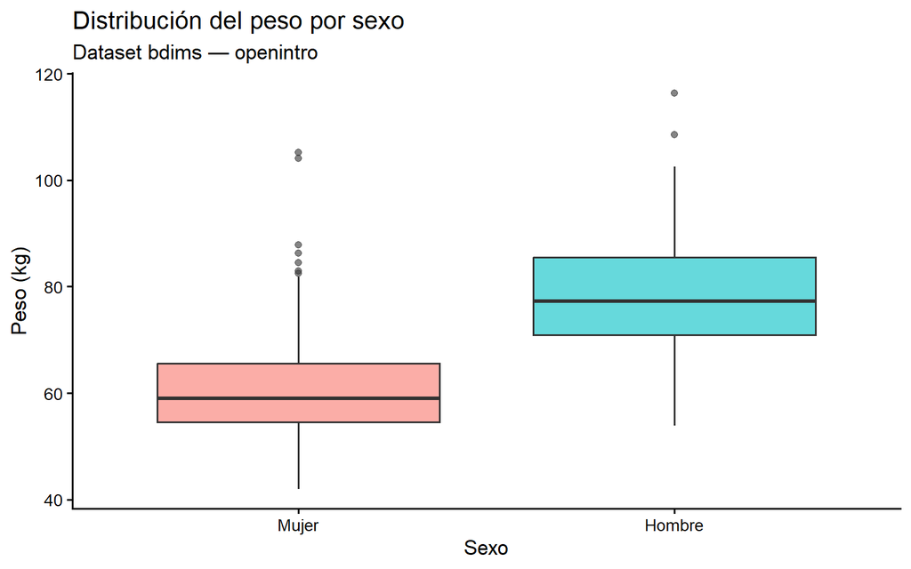

```r
# b) Exploración visual
bdims |>
  ggplot(aes(x = sex, y = wgt, fill = sex)) +
  geom_boxplot(alpha = 0.6) +
  labs(
    title    = "Distribución del peso por sexo",
    subtitle = "Dataset bdims — openintro",
    x        = "Sexo",
    y        = "Peso (kg)"
  ) +
  theme(legend.position = "none")
```

El boxplot muestra claramente que los hombres tienen pesos mayores que las mujeres tanto en mediana como en dispersión.

**c)**

**Código**

```r
# c) Prueba t de dos muestras (Welch por defecto)
t.test(wgt ~ sex, data = bdims)
```

```
    Welch Two Sample t-test

data:  wgt by sex
t = -19.577, df = 495.27, p-value < 2.2e-16
alternative hypothesis: true difference in means between group Mujer and group Hombre is not equal to 0
95 percent confidence interval:
 -19.30486 -15.78344
sample estimates:
 mean in group Mujer mean in group Hombre
            60.60038             78.14453
```

**d)** El p-valor es extremadamente pequeño (muy inferior a 0.05), y el intervalo de confianza de la diferencia de medias **no contiene el 0**. Ambos criterios llevan a **rechazar** $H_0$ con evidencia muy fuerte.

**e)** Hay evidencia estadística sólida de que el peso promedio es significativamente diferente entre hombres y mujeres en esta muestra: los hombres tienen en promedio un peso considerablemente mayor que las mujeres.

## Resumen de Funciones Utilizadas

A continuación se presenta un resumen de las principales funciones de `R` empleadas en esta guía:

| Función | Paquete | Descripción |
| --- | --- | --- |
| `mean(condición)` | base R | Proporción de casos que cumplen la condición (probabilidad empírica) |
| `sample()` | base R | Muestreo aleatorio con o sin reemplazo |
| `set.seed()` | base R | Fija la semilla para reproducibilidad |
| `dbinom(x, size, prob)` | stats | pmf de la binomial: $P(X = x)$ |
| `pbinom(x, size, prob)` | stats | cdf de la binomial: $P(X \leq x)$ |
| `pnorm(x, mean, sd)` | stats | cdf de la normal: $P(X \leq x)$ |
| `qnorm(p, mean, sd)` | stats | Cuantil de la normal: valor que deja probabilidad $p$ a la izquierda |
| `t.test(x)` | stats | IC y prueba t para la media de una muestra |
| `t.test(y ~ x, data)` | stats | Prueba t de Welch para dos muestras independientes |
| `qt(p, df)` | stats | Cuantil de la distribución *t* con `df` grados de libertad |
| `geom_boxplot()` | ggplot2 | Gráfico de caja |

**Bibliografía de Referencia**

- Çetinkaya-Rundel, M. & Hardin, J. (2024). *Introduction to Modern Statistics* (2a ed.). OpenIntro. Disponible en: https://openintro-ims.netlify.app/
- Devore, J. L. (2016). *Probabilidad y estadística para ingeniería y ciencias* (9a ed.). CENGAGE Learning.
- Agresti, A. (2018). *Statistical Methods for the Social Sciences* (5a ed.). Pearson.

## Referencias

Çetinkaya-Rundel, Mine, y Johanna Hardin. 2024. *Introduction to modern statistics*. 2e ed. Vereinigte Staaten: OpenIntro, Inc. https://openintro-ims.netlify.app/.

Devore, Jay L. 2016. *Probabilidad y estadística para ingeniería y ciencias (9a. ed.)*. Distrito Federal: CENGAGE Learning.

Heinz, Grete, Louis J. Peterson, Roger W. Johnson, y Carter J. Kerk. 2003. «Exploring Relationships in Body Dimensions». *Journal of Statistics Education* 11 (2): 7. https://doi.org/10.1080/10691898.2003.11910711.